# MultiConnector: Complete Guide to One-Dimensional Functional Clustering

Step-by-Step Analysis of Time Series Data

MultiConnector Development Team

2026-02-25

This guide demonstrates how to perform functional clustering analysis on one-dimensional time series data using the **MultiConnector** package. We use ovarian cancer cell growth data as a case study to illustrate the complete workflow from data import to biological interpretation. The analysis identifies distinct growth patterns and relates them to cellular progeny information, providing insights into cancer cell behavior and potential therapeutic targets.

# Introduction

## Background

Functional clustering is a powerful statistical method for analyzing time series data where the goal is to group curves based on their shape and temporal patterns rather than individual time points. This approach is particularly valuable in biological and medical research where understanding distinct temporal patterns can reveal important insights about:

- Disease progression patterns
- Treatment response profiles
- Cellular growth dynamics
- Biomarker trajectories

## The MultiConnector Package

**MultiConnector** implements advanced functional clustering methods based on the Sugar & James model, which:

- Projects curves onto lower-dimensional spaces using spline coefficients
- Accounts for within-curve correlation and measurement error
- Provides robust clustering solutions through multiple random initializations
- Offers comprehensive visualization and validation tools

## Case Study: Ovarian Cancer Cell Growth

In this guide, we analyze ovarian cancer cell line growth curves to:

1. **Identify distinct growth patterns** in cancer cell populations
2. **Relate patterns to progeny information** to understand cellular heterogeneity
3. **Demonstrate the complete analysis workflow** for one-dimensional functional clustering

# Getting Started

## Installation and Setup

```r
# Load required libraries
library(dplyr) # Data manipulation
library(parallel) # Parallel computing
library(MultiConnector) # Main clustering package
library(ggplot2) # Enhanced plotting
library(knitr) # Table formatting
library(kableExtra) # Enhanced table styling

# Set up parallel processing
n_cores <- detectCores()
workers <- max(1, n_cores - 1) # Leave one core free

cat("System Information:\n")
```

```
#> System Information:
```

```r
cat("- Available CPU cores:", n_cores, "\n")
```

```
#> - Available CPU cores: 8
```

```r
cat("- Cores used for analysis:", workers, "\n")
```

```
#> - Cores used for analysis: 7
```

## Data Requirements

For one-dimensional functional clustering, your data should include:

- **Time series data**: With columns `subjID`, `measureID`, `time`, `value`
- **Annotation data**: With `subjID` and feature columns (e.g., treatment groups, demographics)
- **Consistent identifiers**: Matching IDs between time series and annotations

# Data Import and Preparation

## Creating the CONNECTORData Object

The `ConnectorData()` function validates and structures the data for analysis:

```r
system.file("Data/OvarianCancer/Ovarian_TimeSeries.xlsx", package = "MultiConnector") -> time_series_path
system.file("Data/OvarianCancer/Ovarian_Annotations.csv", package = "MultiConnector") -> annotations_path
# Create the main data object
Data <- ConnectorData(time_series_path, annotations_path)
```

```
#> ###############################
#> ######## Summary ##############
#>
#>  Number of Observations:# A tibble: 1 × 1
#>   nTimePoints
#>         <int>
#> 1          21
#> ;
#>  Min curve length: # A tibble: 1 × 1
#>   nTimePoints
#>         <int>
#> 1           7
#> ; Max curve length: # A tibble: 1 × 1
#>   nTimePoints
#>         <int>
#> 1          18
#> ###############################
```

# Initial Data Exploration

Understanding your data structure is crucial before clustering. We examine:

1. **Overall growth patterns**
2. **Feature relationships**
3. **Time point distributions**

## Basic Time Series Visualization

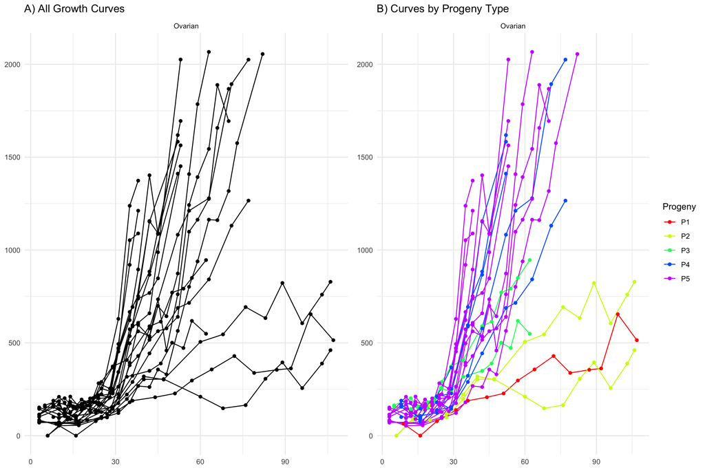

Initial data exploration: (A) All growth curves overlaid, (B) Curves colored by progeny type.

```r
# Plot 1: Basic time series overview
p1 <- plot(Data) +
  ggtitle("A) All Growth Curves") +
  theme_minimal()

# Plot 2: Colored by progeny feature
p2 <- plot(Data, feature = "Progeny") +
  ggtitle("B) Curves by Progeny Type") +
  theme_minimal()

# Combine plots if possible (requires gridExtra or patchwork)
if (requireNamespace("gridExtra", quietly = TRUE)) {
  gridExtra::grid.arrange(p1, p2, ncol = 2)
} else {
  print(p1)
  print(p2)
}
```

## Time Point Distribution Analysis

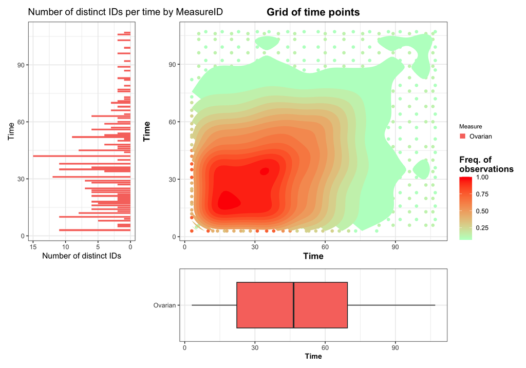

Time point distribution analysis showing data density across the measurement period.

```r
# Analyze time point distributions
plotTimes(Data, large = TRUE)
```

### Key Observations

From the initial exploration, we can observe:

- **Growth curve diversity**: Multiple distinct patterns are visible
- **Feature associations**: Some progeny types may show preferred growth patterns
- **Data completeness**: Time point coverage affects analysis quality

# Data Preprocessing

## Truncation Analysis

Many time series datasets have sparse data at later time points. Truncation can improve clustering stability by focusing on well-sampled regions.

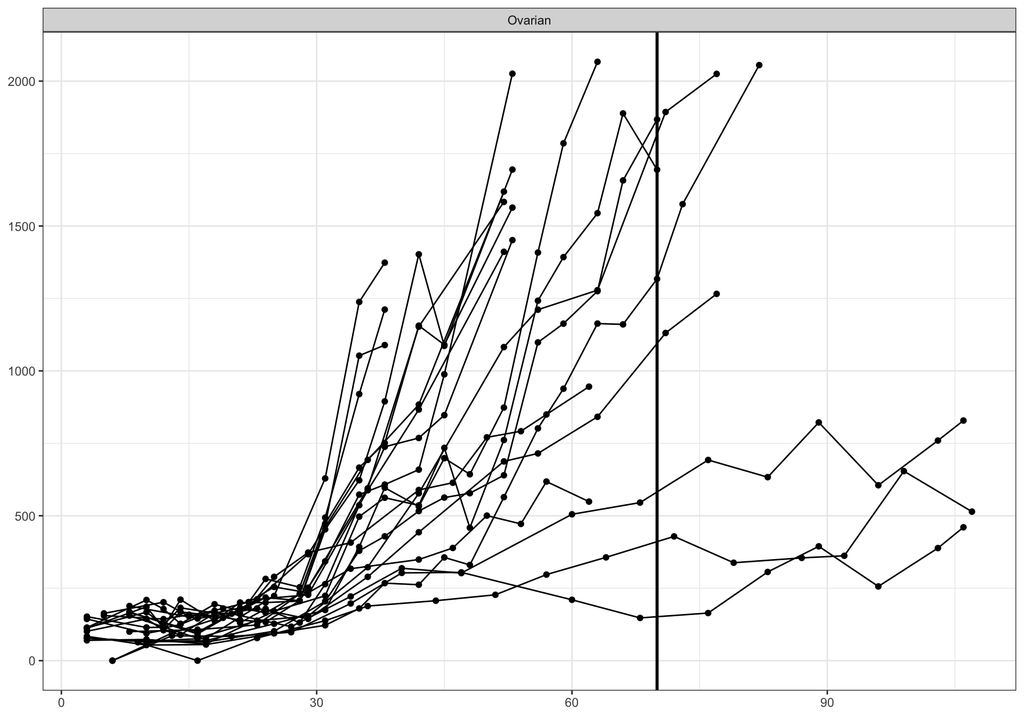

Truncation analysis helping to identify optimal cutoff time for maintaining data quality.

```r
# Analyze truncation effects
truncatePlot(Data, measure = "Ovarian", truncTime = 70)
```

```r
# Apply truncation based on analysis
DataTrunc <- truncate(Data, measure = "Ovarian", truncTime = 70)
```

```
#> ###############################
#> ######## Summary ##############
#>
#>  Number of curves:# A tibble: 1 × 1
#>   nTimePoints
#>         <int>
#> 1          21
#> ;
#>  Min curve length: # A tibble: 1 × 1
#>   nTimePoints
#>         <int>
#> 1           7
#> ; Max curve length: # A tibble: 1 × 1
#>   nTimePoints
#>         <int>
#> 1          16
#> ###############################
```

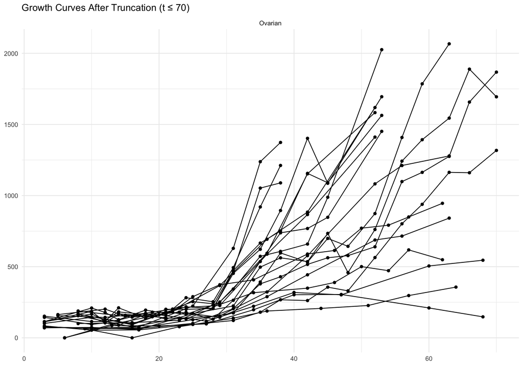

Data after truncation at time = 70, showing improved data density.

```r
# Visualize truncated data
plot(DataTrunc) +
  ggtitle("Growth Curves After Truncation (t ≤ 70)") +
  theme_minimal()
```

# Parameter Estimation

## Spline Dimension Selection

The spline dimension (`p`) parameter controls curve flexibility:

- **Higher p**: More flexible curves, risk of overfitting
- **Lower p**: Smoother curves, may miss important features

```r
# Estimate optimal spline dimension
CrossLogLikePlot <- estimatepDimension(DataTrunc, p = 2:6, cores = workers)
```

```
#> [1] "Total time for  Ovarian : 8.71 secs"
#> [1] "Total time: 8.72 secs"
```

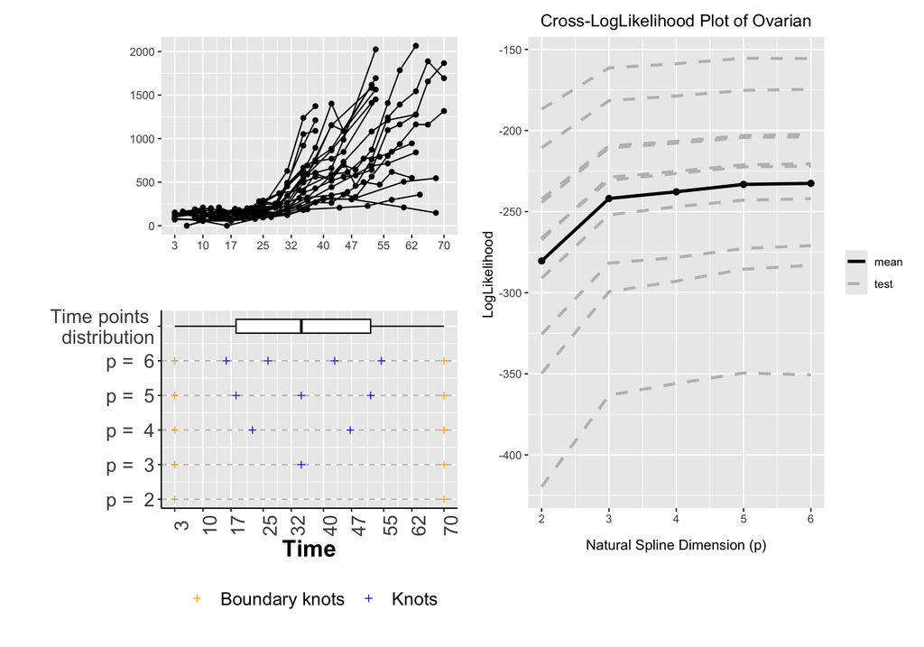

Cross-validation results for spline dimension selection showing optimal p value.

```r
# Display results
print(CrossLogLikePlot)
```

```r
# Set optimal value (typically where CV error is minimized)
optimal_p <- 3
cat("Selected optimal p =", optimal_p, "\n")
```

```
#> Selected optimal p = 3
```

### Parameter Selection Guidelines

| p Value | Characteristics | Best For |
| --- | --- | --- |
| 2-3 | Smooth, simple curves | Linear/quadratic patterns |
| 4-5 | Moderate flexibility | Complex but stable patterns |
| 6+ | High flexibility | Complex curves (risk overfitting) |

# Clustering Analysis

## Comprehensive Clustering

We test multiple cluster numbers to find the optimal solution:

```r
# Perform clustering analysis
# Note: Since p is a single value, a warning will be issued indicating
# it's being recycled for all measures. This is expected.
clusters <- estimateCluster(
  DataTrunc,
  G = 2:6, # Test 2-6 clusters
  p = optimal_p, # Use optimal spline dimension
  runs = 20, # Reduced for demonstration (use 100+ for final analysis)
  cores = workers # Parallel processing
)
```

```
#> [1] "Total time: 4.58 secs"
```

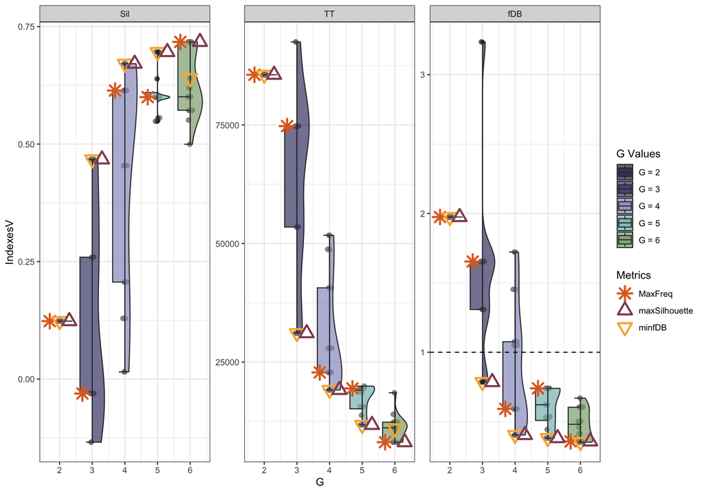

Clustering quality metrics across different numbers of clusters (G).

```r
# Display quality metrics
plot(clusters)
```

### Quality Metrics Interpretation

- **fDB (functional Data Depth)**: Lower values indicate more compact, well-separated clusters
- **Silhouette Score**: Higher values (closer to 1) indicate better cluster quality
- **Stability**: Consistent results across multiple runs indicate robust solutions

## Cluster Selection

Based on quality metrics, we select the optimal configuration:

```r
# Select optimal clustering (G=4 based on quality metrics)
ClusterData <- selectCluster(clusters, G = 4, "MinfDB")
```

Selected Configuration:

- Number of clusters: 4
- Selection criterion: Minimum fDB
- This represents the most compact and well-separated clustering

# Results Visualization and Interpretation

## Basic Cluster Visualization

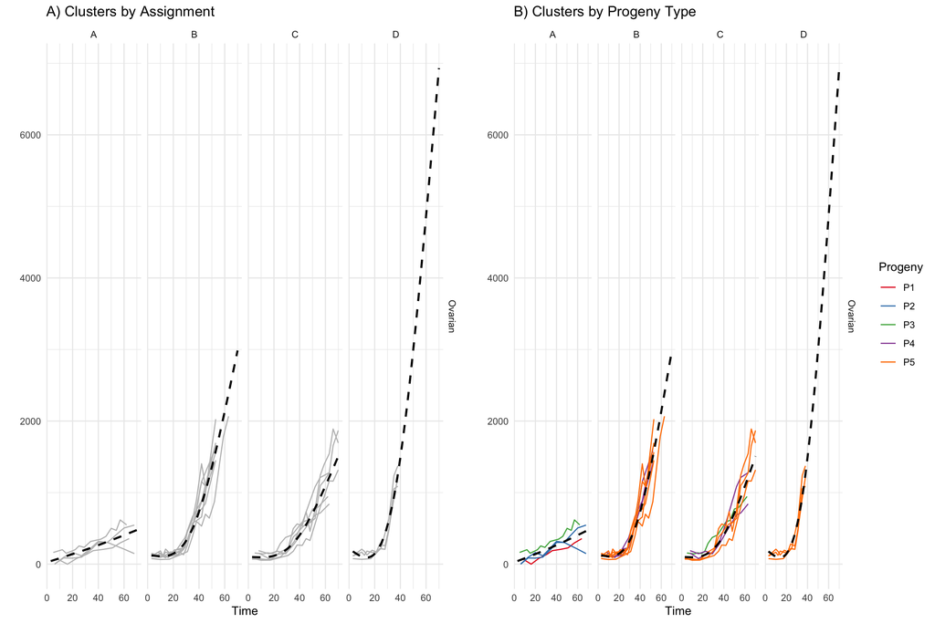

```r
# Plot clusters
p1 <- plot(ClusterData) +
  ggtitle("A) Clusters by Assignment") +
  theme_minimal()

# Plot by progeny feature
p2 <- plot(ClusterData, feature = "Progeny") +
  ggtitle("B) Clusters by Progeny Type") +
  theme_minimal()

# Display plots
if (requireNamespace("gridExtra", quietly = TRUE)) {
  gridExtra::grid.arrange(p1, p2, ncol = 2)
} else {
  print(p1)
  print(p2)
}
```

## Cluster-Feature Association Analysis

```r
# Examine available features
features <- getAnnotations(ClusterData)
cat("Available features:", paste(features, collapse = ", "), "\n")
```

```
#> Available features: IDSample, Progeny, Source, Real.Progeny
```

```r
# Generate distribution table for the main feature
if ("Progeny" %in% features) {
  dist_table <- clusterDistribution(ClusterData, "Progeny")

  kable(dist_table,
    caption = "Cluster-progeny distribution showing how different lineages are grouped."
  ) %>%
    kable_styling(bootstrap_options = c("striped", "hover"))
}
```

Cluster-progeny distribution showing how different lineages are grouped.

| Progeny | A | B | C | D | Total |
| --- | --- | --- | --- | --- | --- |
| P1 | 1 | 0 | 0 | 0 | 1 |
| P2 | 2 | 0 | 0 | 0 | 2 |
| P3 | 1 | 0 | 1 | 0 | 2 |
| P4 | 0 | 3 | 2 | 0 | 5 |
| P5 | 0 | 5 | 3 | 3 | 11 |
| TOTAL | 4 | 8 | 6 | 3 | 21 |
| TOTAL | 4 | 8 | 6 | 3 | 21 |

# Cluster Validation

## Quality Assessment

Comprehensive validation ensures clustering reliability:

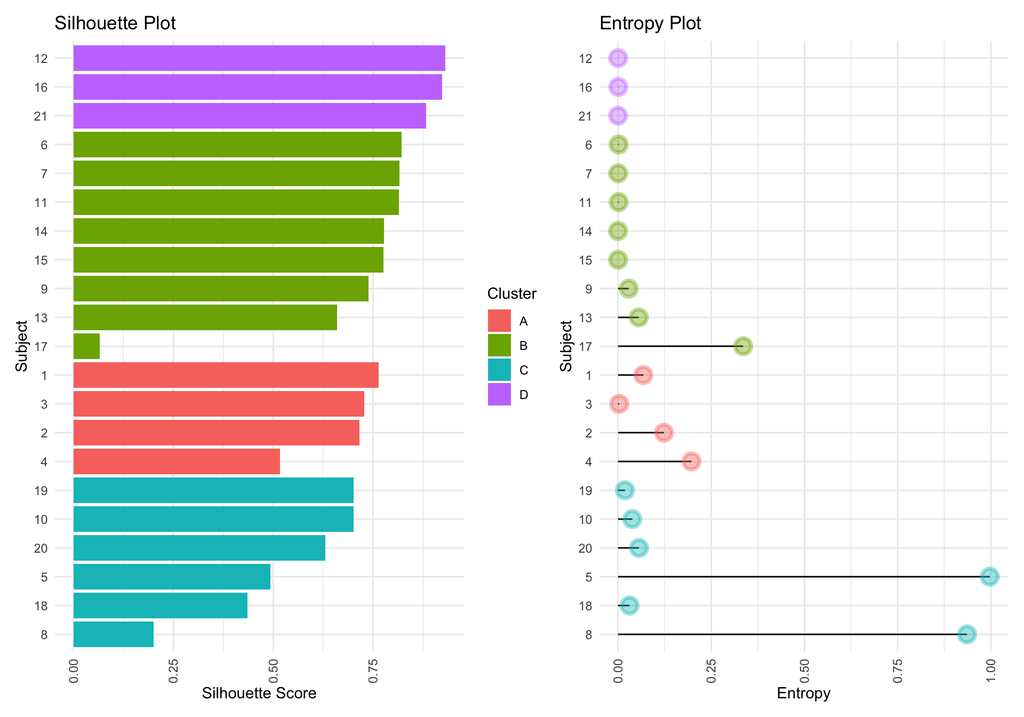

Cluster validation metrics: (A) Silhouette analysis showing how well samples fit their clusters, (B) Entropy analysis measuring assignment uncertainty.

```r
# Perform validation analysis
Metrics <- validateCluster(ClusterData)

# Display validation plots
print(Metrics$plot)
```

### Validation Metrics Interpretation

- **Silhouette Analysis**:
  - Values close to 1: Well-assigned samples
  - Values near 0: Borderline assignments
  - Negative values: Potentially misclassified samples
- **Entropy Analysis**:
  - Low entropy: Confident cluster assignments
  - High entropy: Uncertain assignments requiring investigation

# Advanced Visualizations

## Discriminant Analysis

Discriminant plots show clusters in reduced dimensional space:

```r
# Generate discriminant plots
Discr <- DiscriminantPlot(ClusterData)
```

```
#> [1] "Percentage of variance explained:"
#> [1] 91.731111  5.665049  2.603840
#> [1] "Sum of first two components: 97.4"
```

```r
# Display cluster-colored plot
print(Discr$ColCluster)

# Display feature-colored plot (if features exist)
if ("ColFeature" %in% names(Discr)) {
  print(Discr$ColFeature)
}
```

[output not shown]

## Spline-Based Cluster Representation

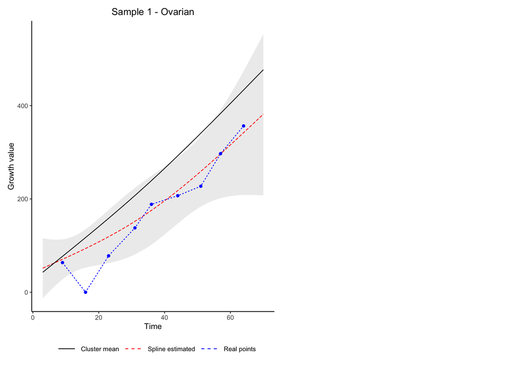

```r
# Generate spline plots
splinePlots <- splinePlot(ClusterData)

# Display the main spline plot
if (length(splinePlots) > 0) {
  print(splinePlots[[1]])
}
```

## Maximum Discrimination Analysis

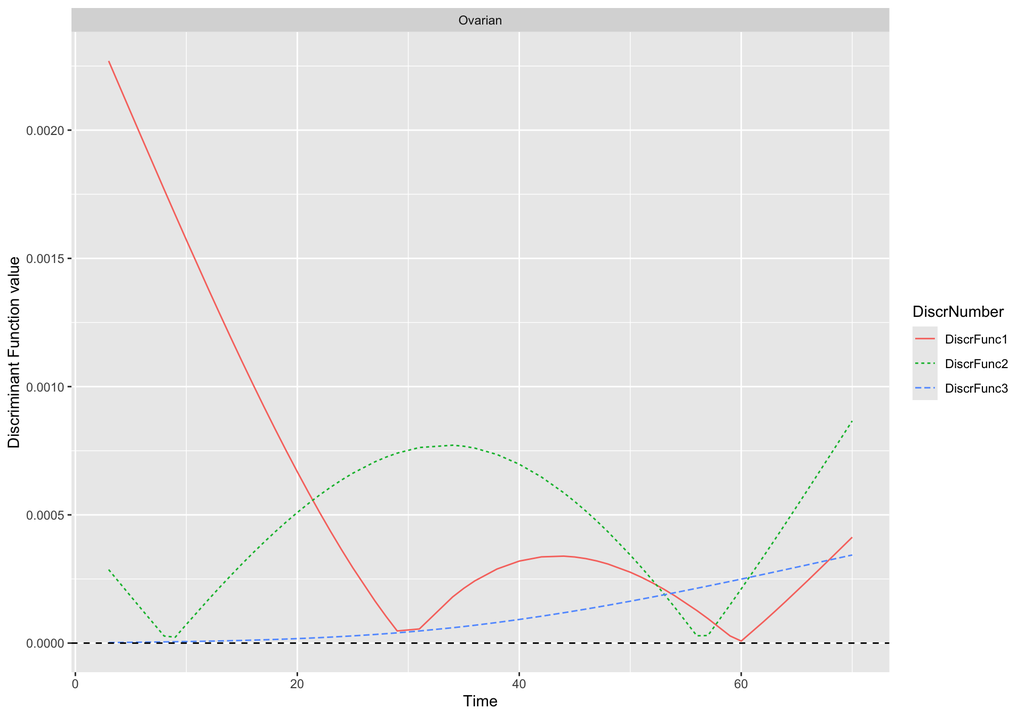

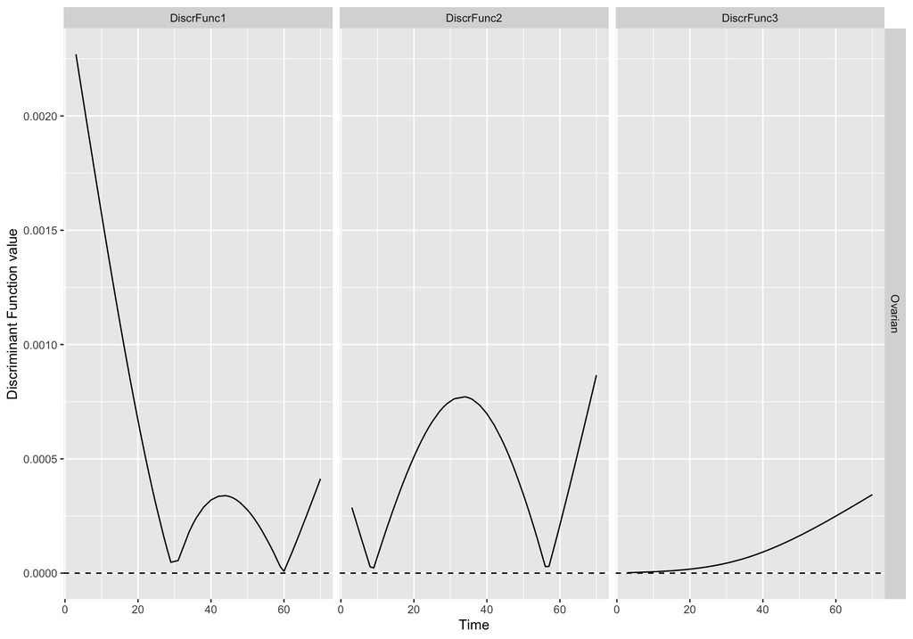

```r
# Identify most discriminative features
MaximumDiscriminationFunction(ClusterData)
```

# Advanced Analysis Functions

This section demonstrates the new advanced analysis capabilities available in MultiConnector for detailed subject-level analysis and comprehensive reporting.

## Automated Reporting with generateReport()

The `generateReport()` function creates a comprehensive analysis summary that can be exported as an HTML report, including all plots, tables, and analysis choices.

```r
# Generate a comprehensive report object
analysis_report <- generateReport(
  data = DataTrunc,
  clustered_data = ClusterData,
  report_title = "Ovarian Cancer Growth Analysis",
  features = "Progeny"
)

# Export to HTML for sharing
generateReport(
  clustered_data = ClusterData,
  report_title = "Ovarian Cancer Final Report",
  output_format = "html",
  output_file = "Ovarian_Analysis_Report.html"
)
```

## Subject-Level Analysis with SubjectInfo()

The `SubjectInfo()` function allows detailed analysis of specific subjects within their clustering context, providing highlighted visualizations and comprehensive information.

```r
# Select some subjects for detailed analysis
selected_subjects <- unique(DataTrunc@annotations$subjID)[1:3]

# Single subject analysis
subject_info <- SubjectInfo(ClusterData, subjIDs = selected_subjects[1])

# Display cluster assignment
cat("Cluster Assignment:")
```

```
#> Cluster Assignment:
```

```r
cat(subject_info$cluster_assignments)
```

```
#> Subject 1 belongs to Cluster 1
```

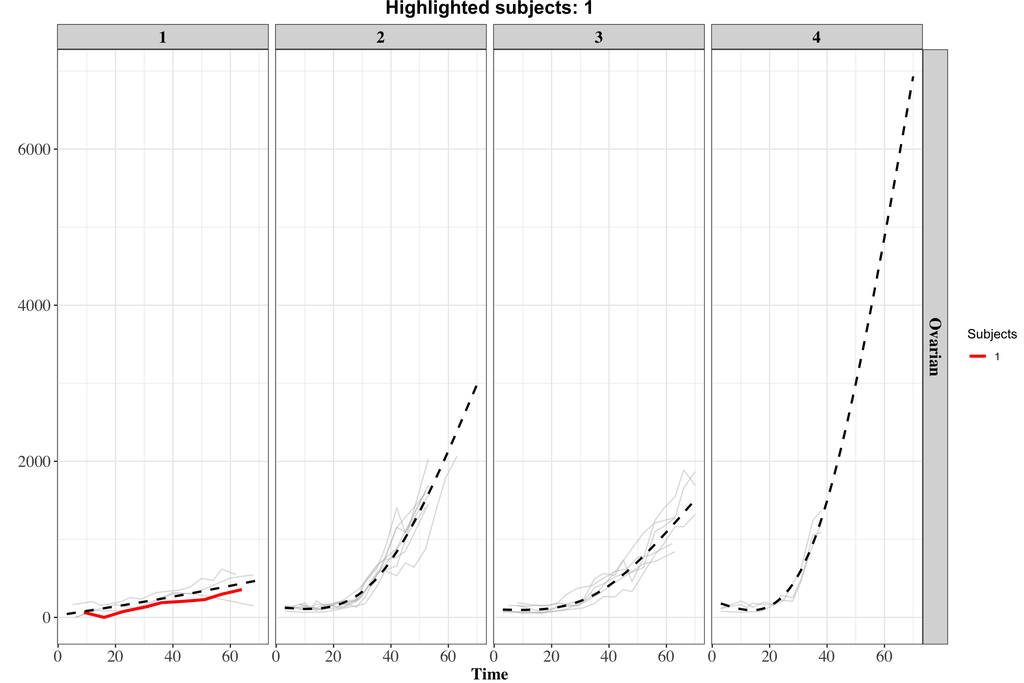

```r
# Show the highlighted plot
subject_info$highlighted_plot
```

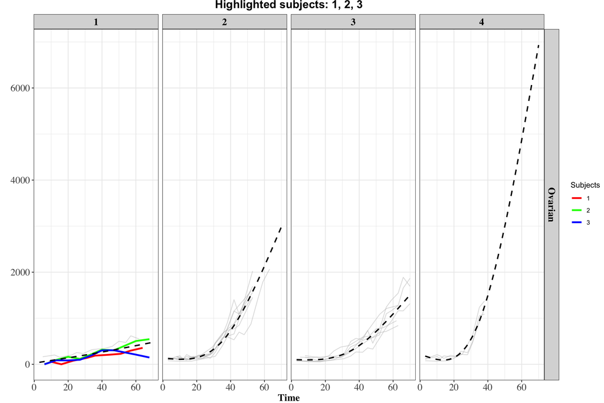

```r
# Multiple subjects comparison
multi_subject_info <- SubjectInfo(ClusterData, subjIDs = selected_subjects)
multi_subject_info$highlighted_plot
```

The `SubjectInfo()` function provides:

- **Cluster assignment**: Which cluster each subject belongs to
- **Highlighted visualization**: Subject curves emphasized in cluster context
- **Quality metrics**: Access to silhouette and entropy measures
- **Subject data**: Complete time series data for the specified subjects

## Cluster Composition Analysis with clusterDistribution()

Analyze how different features are distributed across clusters using cross-tabulation:

```r
progeny_dist <- clusterDistribution(ClusterData, "Progeny")

cat("Progeny Distribution Across Clusters:")
```

```
#> Progeny Distribution Across Clusters:
```

```r
print(progeny_dist)
```

```
#> # A tibble: 7 × 6
#>   Progeny     A     B     C     D Total
#>   <chr>   <int> <int> <int> <int> <dbl>
#> 1 P1          1     0     0     0     1
#> 2 P2          2     0     0     0     2
#> 3 P3          1     0     1     0     2
#> 4 P4          0     3     2     0     5
#> 5 P5          0     5     3     3    11
#> 6 TOTAL       4     8     6     3    21
#> 7 TOTAL       4     8     6     3    21
```

```r
# If other features are available, analyze them too
available_features <- getAnnotations(ClusterData)
cat("\nAvailable features for distribution analysis:")
```

```
#>
#> Available features for distribution analysis:
```

```r
print(available_features)
```

```
#> [1] "IDSample"     "Progeny"      "Source"       "Real.Progeny"
```

```r
# Example with any numeric feature converted to categories
if (length(available_features) > 1) {
  # Take the first available feature for demonstration
  demo_feature <- available_features[1]
  if (demo_feature != "Progeny") { # Avoid duplicate analysis
    tryCatch(
      {
        feature_dist <- clusterDistribution(ClusterData, demo_feature)
        cat("\nDistribution of", demo_feature, "across clusters:")
        print(feature_dist)
      },
      error = function(e) {
        cat("\nCannot analyze feature", demo_feature, ":", e$message)
      }
    )
  }
}
```

```
#>
#> Distribution of IDSample across clusters:# A tibble: 23 × 6
#>    IDSample                A     B     C     D Total
#>    <chr>               <int> <int> <int> <int> <dbl>
#>  1 475_P1b                 1     0     0     0     1
#>  2 475_P1bP2a              1     0     0     0     1
#>  3 475_P1bP2aP3a           1     0     0     0     1
#>  4 475_P1bP2b              1     0     0     0     1
#>  5 475_P1bP2aP3bP4a        0     1     0     0     1
#>  6 475_P1bP2aP3bP4aP5a     0     1     0     0     1
#>  7 475_P1bP2aP3bP4aP5c     0     1     0     0     1
#>  8 475_P1bP2aP3bP4aP5d     0     1     0     0     1
#>  9 475_P1bP2aP3bP4aP5e     0     1     0     0     1
#> 10 475_P1bP2aP3bP4b        0     1     0     0     1
#> # ℹ 13 more rows
```

The `clusterDistribution()` function helps identify:

- **Feature-cluster associations**: Which features are enriched in specific clusters
- **Cluster balance**: Whether clusters are balanced across important covariates
- **Quality control**: Ensuring clustering isn’t driven by confounding variables

# Biological Interpretation

# Conclusions and Next Steps

## Summary of Findings

Our functional clustering analysis revealed:

1. **Four distinct growth patterns** in ovarian cancer cell populations
2. **Associations between growth patterns and progeny types** (if significant)
3. **Robust clustering solution** validated through multiple quality metrics

# References

1. Sugar, C. A., & James, G. M. (2003). Finding the number of clusters in a dataset: An information-theoretic approach. *Journal of the American Statistical Association*, 98(463), 750-763.
2. James, G. M., & Sugar, C. A. (2003). Clustering for sparsely sampled functional data. *Journal of the American Statistical Association*, 98(462), 397-408.
3. Ramsay, J. O., & Silverman, B. W. (2005). *Functional data analysis*. Springer.
4. Ferraty, F., & Vieu, P. (2006). *Nonparametric functional data analysis: theory and practice*. Springer.

# Appendix

## Computational Details

- **Analysis performed on**: 2026-02-25 14:52:59.456562
- **R version**: R version 4.5.2 (2025-10-31)
- **Cores used**: 7
- **Total computation time**: Varies with dataset size and parameters

## Troubleshooting Common Issues

### Data Format Problems

- Ensure column names match requirements (`subjID`, `measureID`, `time`, `value`)
- Check for missing values in key columns
- Verify ID consistency between time series and annotations

### Convergence Issues

- Reduce spline dimension (`p`) if clustering fails
- Increase number of runs for stability
- Consider data truncation to remove sparse regions

### Memory and Performance

- Use fewer clusters or runs for large datasets
- Utilize parallel processing with `cores` parameter
- Consider data subsampling for initial exploration

*This guide was generated using the MultiConnector package. For updates and additional resources, visit the package documentation.*